# Ficha Colombia

COLOMBIA  
[S.G de Análisis migratorio](https://www.inclusion.gob.es/web/opi/estadisticas)  
16/05/2023

1. Ciudadanos con documentación de residencia en vigor  
2. Otros documentados y estimación de personas sin documentación de residencia  
3. Perfil socio-demográfico y distribución territorial  
4. Afiliación en alta laboral y paro registrado  
5. Nacionalizados españoles por residencia  
6. Solicitantes de Protección Internacional  
7. Beneficiarios del sistema de acogida  
8. Menores no acompañados registrados en el Registro MENAs  
9. Evolución de los flujos regulares (visados y documentación de residencia)  
10. Población española residente en Colombia

# 1. Ciudadanos con documentación de residencia en vigor

A fecha 30/06/2022 constaban **166.489 ciudadanos de nacionalidad colombiana con documentación de residencia en vigor en España**:

- 101.799 con Autorización de Régimen General en alguna de las modalidades previstas en la normativa de extranjería española.
- 64.494 con Tarjeta de familiar de ciudadano comunitario en virtud de sus vínculos familiares con algún ciudadano de la UE/AELC.
- 196 con Documento (TIE) del Acuerdo de Retirada como familiar de ciudadano británico beneficiario del acuerdo motivado por el Brexit e iniciado el 6 de julio de 2020.

Nacionales de Colombia con autorización de residencia según motivo de concesión. 30/06/2022

| Motivo | Personas | % |
| --- | --- | --- |
| TOTAL | 101.799 | 100 |
| Residencia de larga duración | 56.710 | 56 |
| Arraigo | 22.716 | 22 |
| Residencia temporal. Trabajo cuenta ajena | 10.542 | 10 |
| Residencia temporal no lucrativa | 3.215 | 3 |
| Reagrupación familiar | 3.023 | 3 |
| Circunstancias excepcionales | 2.704 | 3 |
| Ley 14/2013 y otras | 2.349 | 2 |
| Residencia temporal. Trabajo cuenta propia | 491 | 0 |
| Residencia duración determinada. Trabajo cuenta ajena | 49 | 0 |

Fuente: [OPI - SGAM](https://www.inclusion.gob.es/web/opi/estadisticas/catalogo/extranjeros_con_certificado)

Nacionales de Colombia con tarjeta de familiar de ciudadano comunitario o con TIE de familiar de británico beneficiario del acuerdo de retirada, según motivo. 30/06/2022

| Modalidad | Personas | % |
| --- | --- | --- |
| TOTAL | 64.690 | 100 |
| Familiar No UE. No permanente | 46.991 | 73 |
| Familiar No UE. Permanente | 17.503 | 27 |
| Familiar de británico. Residencia temporal | 164 | 0 |
| Familiar de británico. Residencia permanente | 31 | 0 |
| Titular británico. Residencia temporal | 1 | 0 |

Fuente: [OPI - SGAM](https://www.inclusion.gob.es/web/opi/estadisticas/catalogo/extranjeros_con_certificado)

La comunidad de Colombia representa un **16% de todos los ciudadanos de América Central y del Sur documentados en España.**

Nacionales de Colombia con documentación de residencia en España según tipo de documentación en vigor y región. 30/06/2022

| Tipo documentación | TOTAL | Nacionales de América Central y del Sur | % América Central y del Sur respecto Total | Nacionales de Colombia | % Colombia respecto América Central y del Sur |
| --- | --- | --- | --- | --- | --- |
| TOTAL | 6.246.130 | 1.067.281 | 17,09 | 166.489 | 15,60 |
| Autorización | 2.520.176 | 707.465 | 28,07 | 101.799 | 14,39 |
| Tarjeta familiar de UE/AELC | 3.530.699 | 359.042 | 10,17 | 64.494 | 17,96 |
| TIE-Acuerdo de retirada | 195.255 | 774 | 0,40 | 196 | 25,32 |

Fuente: [OPI - SGAM](https://www.inclusion.gob.es/web/opi/estadisticas/catalogo/extranjeros_con_certificado)

**En la UE, España ocupa el puesto 1 en número de extranjeros documentados de Colombia**, según datos de Eurostat de finales de 2021.

Nacionales de Colombia con permiso de residencia en cada país de la UE/AELC según tiempo de validez del permiso. 31/12/2021

| Orden | País UE/AELC | TOTAL | De 3 a 5 meses | De 6 a 11 meses | 1 año o más |
| --- | --- | --- | --- | --- | --- |
| 1 | España | 159.148 | 197 | 2.958 | 155.993 |
| 2 | Italia | 19.524 | 6 | 644 | 18.874 |
| 3 | Francia | 17.842 | 455 | 2.758 | 14.629 |
| 4 | Alemania | 13.544 | 69 | 600 | 12.875 |
| 5 | Suiza | 5.288 | 4 | 75 | 5.209 |
| 6 | Países Bajos | 4.011 | 8 | 70 | 3.933 |
| 7 | Bélgica | 2.184 | 152 | 0 | 2.032 |
| 8 | Suecia | 2.183 | 34 | 68 | 2.081 |
| 9 | Portugal | 1.690 | 1 | 29 | 1.660 |
| 10 | Austria | 1.147 | 6 | 97 | 1.044 |
| 11 | Malta | 1.074 | 128 | 85 | 861 |
| 12 | Noruega | 793 | 3 | 65 | 725 |
| 13 | República Checa | 519 | 2 | 17 | 500 |
| 14 | Polonia | 487 | 19 | 121 | 347 |
| 15 | Hungría | 469 | 21 | 59 | 389 |
| 16 | Irlanda | 341 | 3 | 58 | 280 |
| 17 | Finlandia * | 304 | 2 | 59 | 243 |
| 18 | Luxemburgo | 257 | 0 | 5 | 252 |
| 19 | Grecia | 240 | 0 | 0 | 240 |
| 20 | Rumanía | 223 | 3 | 22 | 198 |
| 21 | Estonia | 98 | 0 | 1 | 97 |
| 22 | Croacia | 93 | 3 | 27 | 63 |
| 23 | Eslovenia | 68 | 0 | 2 | 66 |
| 24 | Bulgaria | 65 | 0 | 8 | 57 |
| 25 | Eslovaquia | 63 | 0 | 5 | 58 |
| 26 | Lituania | 56 | 0 | 3 | 53 |
| 27 | Chipre | 49 | 2 | 4 | 43 |
| 28 | Letonia | 24 | 0 | 6 | 18 |
| 29 | Liechtenstein | 20 | 0 | 2 | 18 |
| - | Dinamarca | : | : | : | : |
| - | Islandia | : | : | : | : |

(*) dato de 2020; (:) dato no disponible

Fuente: [Eurostat](https://ec.europa.eu/eurostat/databrowser/view/migr_resvalid/default/table?lang=en)

# 2. Otros documentados y estimación de personas sin documentación de residencia

2.1 Personas con Autorización de Estancia por Estudios

A 30/06/2022 constaban **5.338 nacionales de Colombia documentados con una autorización de estancia por estudios**, 41% hombres y 59% mujeres.

| Tipo de solicitante | TOTAL | Hombres | Mujeres |
| --- | --- | --- | --- |
| TOTAL | 5.338 | 2.199 | 3.139 |
| Estudiante | 5.118 | 2.102 | 3.016 |
| Familiar | 220 | 97 | 123 |

Fuente: [OPI - SGAM](https://www.inclusion.gob.es/web/opi/estadisticas/catalogo/extranjeros_estudios)

2.2 Solicitantes de asilo pendientes de resolución

La información publicada en la web pública de Eurostat indica que, a 31/03/2023 (último dato disponible), había **47.170 personas de nacionalidad colombiana que tenían pendiente de resolución su solicitud de Protección Internacional**; el 50% mujeres.

Fuente: [Eurostat](https://ec.europa.eu/eurostat/databrowser/view/migr_asypenctzm/default/table?lang=en)

2.3 Empadronados y estimación de personas sin documentación de residencia

| Documentación | Personas |
| --- | --- |
| Empadronados a 01/01/2022 | 314.679 |
| Con documentación de residencia a 31/12/2021 | 0 |
| Con autorización de estancia por estudios a 31/12/2021 | 4.753 |
| Solicitantes de asilo pendiente de resolución a 31/12/2021 | 20.320 |
| Empadronados sin documentación en vigor (estimación) | 289.606 |

Fuente: [Padrón Continuo - INE](https://www.ine.es/dyngs/INEbase/es/operacion.htm?c=Estadistica_C&cid=1254736177012&menu=ultiDatos&idp=1254734710990); [OPI - SGAM](https://www.inclusion.gob.es/web/opi/estadisticas/catalogo); [Eurostat](https://ec.europa.eu/eurostat/databrowser/view/migr_asypenctzm/default/table?lang=en)

# 3. Perfil socio-demográfico y distribución territorial

Nacionales de Colombia con documentación de residencia según sexo y grupo de edad. 30/06/2022

| TOTAL | Hombres | % Hombres | Mujeres | % Mujeres |
| --- | --- | --- | --- | --- |
| 166.489 | 75.239 | 45 | 91.250 | 55 |

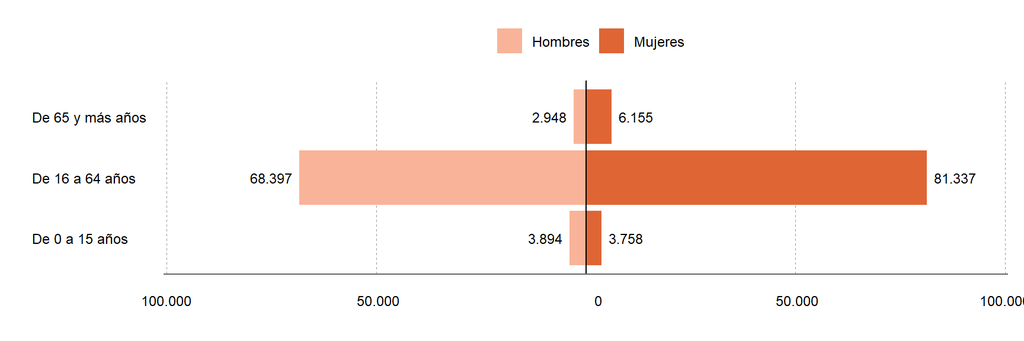

Nacionales de Colombia con documentación de residencia según provincia de residencia. 30/06/2022

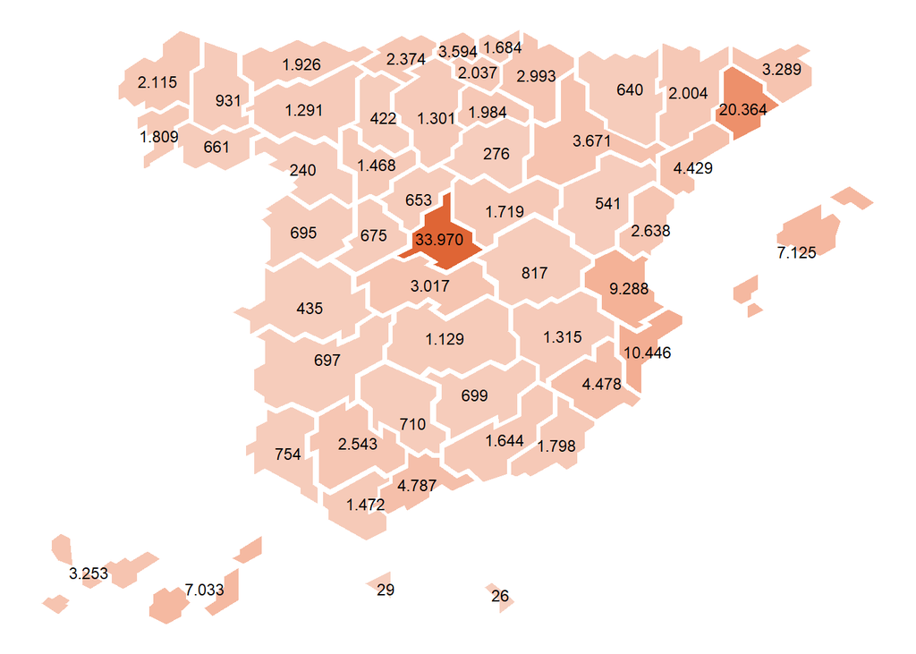

Fuente: [OPI - SGAM](https://www.inclusion.gob.es/web/opi/estadisticas/catalogo/extranjeros_con_certificado)

# 4. Afiliación en alta laboral y paro registrado

4.1 Régimen de afiliación a la Seguridad Social de nacionales de Colombia a 28/04/2023

En España constan **149.472 afiliados de Colombia**, que representan un 8,6% del total de ciudadanos de países no UE/AELC en alta laboral. 74.737 (50%) son hombres y 74.729 (50%) mujeres; hay 6 personas con sexo ‘No consta’.

| Régimen | Afiliados de Colombia | Afiliados no UE/AELC | % Colombia sobre no UE/AELC |
| --- | --- | --- | --- |
| TOTAL | 149.472 | 1.745.903 | 8,6 |
| Régimen General | 119.893 | 591.769 | 20,3 |
| R.G. - S.E. Empleados/as hogar | 13.718 | 100.785 | 13,6 |
| R.E. Autónomos/as | 12.789 | 75.973 | 16,8 |
| R.G. - S.E. Agrario | 3.017 | 24.710 | 12,2 |
| R.E. Mar (cuenta ajena) | 50 | 555 | 9,0 |
| R.E. Mar (cuenta propia) | 5 | 20 | 25,0 |
| R.E. Minería carbón | 0 | 1 | 0,0 |

Afiliados nacionales de Colombia en alta laboral según régimen y sexo. 28/04/2023

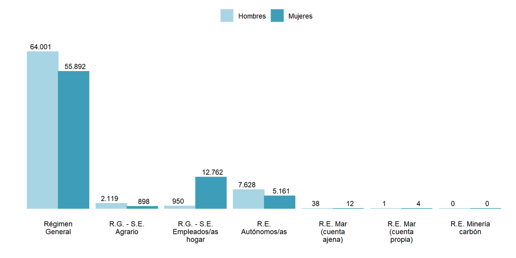

Fuente: [Seguridad Social - MISSM](https://www.seg-social.es/wps/portal/wss/internet/EstadisticasPresupuestosEstudios/Estadisticas/EST8/EST10/EST305/EST307/EST314)

4.2 Parados registrados en el SEPE nacionales de Colombia (Abril 2023)

Hay en España **17.509 parados registrados nacionales de Colombia**, 5.940 (34%) hombres y 11.569 (66%) mujeres.

| TOTAL | Sexo Hombres | Sexo Mujeres | Grupo de edad 16-24 años | Grupo de edad 25-34 años | Grupo de edad 35-44 años | Grupo de edad 45-54 años | Grupo de edad 55 y más años |
| --- | --- | --- | --- | --- | --- | --- | --- |
| 17.509 | 5.940 | 11.569 | 1.293 | 5.055 | 4.965 | 3.758 | 2.438 |
| % | 34 | 66 | 7 | 29 | 28 | 21 | 14 |

Parados registrados en el SEPE nacionales de Colombia según comunidad autónoma. Abril 2023

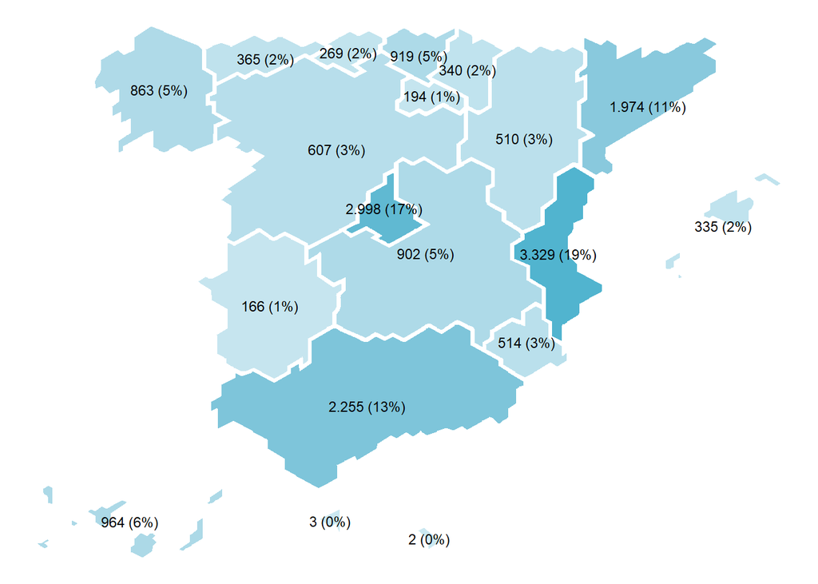

Fuente: [Servicio Público de Empleo Estatal (SEPE)](https://www.sepe.es/HomeSepe/que-es-el-sepe/estadisticas.html)

# 5. Nacionalizados españoles por residencia

**Desde 2009 se han nacionalizado españoles por residencia un total de 184.967 personas con nacionalidad previa colombiana.**

En 2021 obtuvieron la nacionalidad por residencia 12.364 personas.

Evolución de las concesiones de nacionalidad española por residencia a ciudadanos de Colombia. 2009─2021

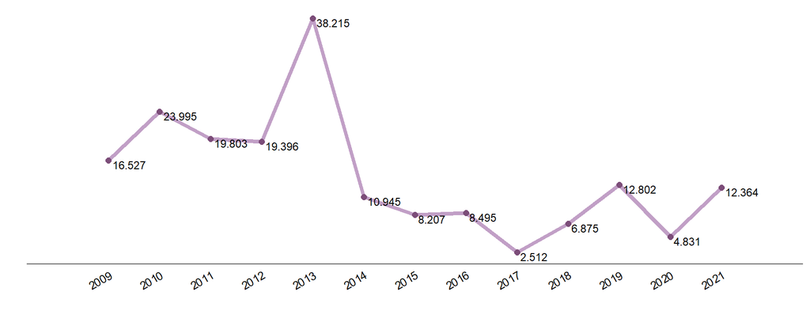

Nota: En 2017 hubo una reducción generalizada de las concesiones de nacionalidad por causas administrativas.

Concesiones de nacionalidad española por residencia a ciudadanos de Colombia según plazo exigido / motivo. 2021

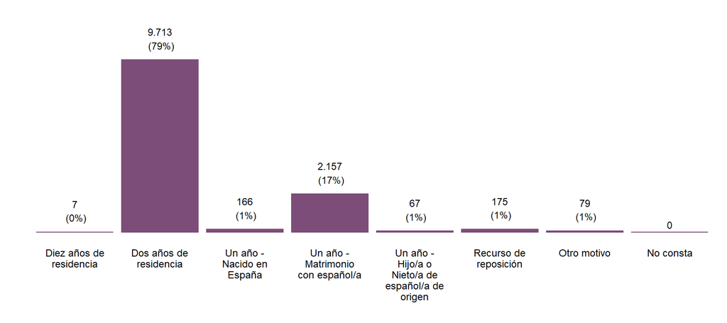

Nota: Existen casos en los que la nacionalidad de origen grabada no coincide con la vía de acceso a la nacionalidad española que debería corresponder según la legislación. Sin embargo, en este momento no se dispone de suficiente información para su correcta depuración.

Concesiones de nacionalidad española por residencia a ciudadanos de Colombia según sexo y edad. 2021

| TOTAL | Hombres | % Hombres | Mujeres | % Mujeres |
| --- | --- | --- | --- | --- |
| 12.364 | 4.831 | 39 | 7.533 | 61 |

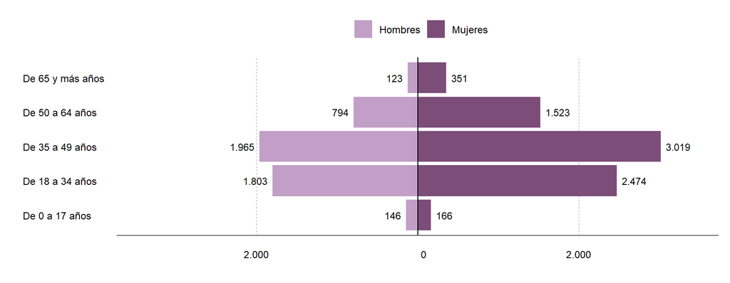

Fuente: [OPI - SGAM](https://www.inclusion.gob.es/web/opi/estadisticas/catalogo/concesiones_nacionalidad)

# 6. Solicitantes de Protección Internacional

**Durante 2022 36.012 personas nacionales de Colombia solicitaron Protección Internacional** en el territorio de España, embajadas españolas, puestos fronterizos o CIE. Suponen un 30,3% del total de solicitantes del periodo.

Según avance mensual, **de enero a abril de 2023 solicitaron Protección Internacional 17.481 personas con nacionalidad Colombia**, un 33% del total del periodo.

Evolución de los solicitantes de Protección Internacional nacionales de Colombia y su distribución según sexo. 2017─2022

(No se han publicado aún datos desagregados por sexo para 2022)

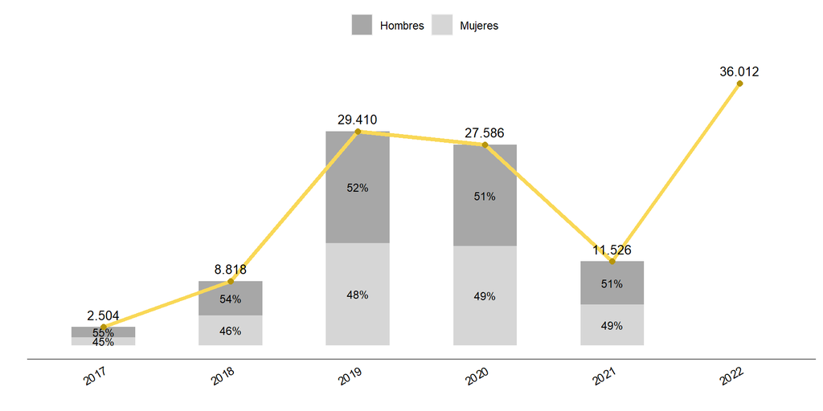

Solicitantes de Protección Internacional nacionales de Colombia según lugar de presentación de la solicitud. 2021

(No se han publicado aún datos para 2022)

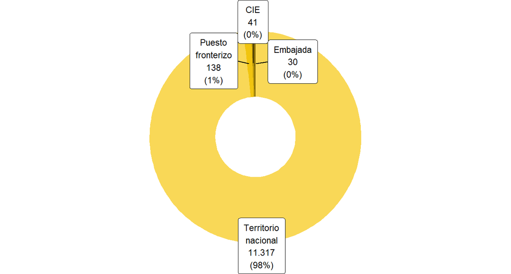

**Durante 2022 se resolvieron 16.187 solicitudes de Protección Internacional de personas con nacionalidad colombiana.** El 5% fueron favorables.

Evolución de las resoluciones de solicitudes de Protección Internacional de personas nacionales de Colombia. 2017─2022

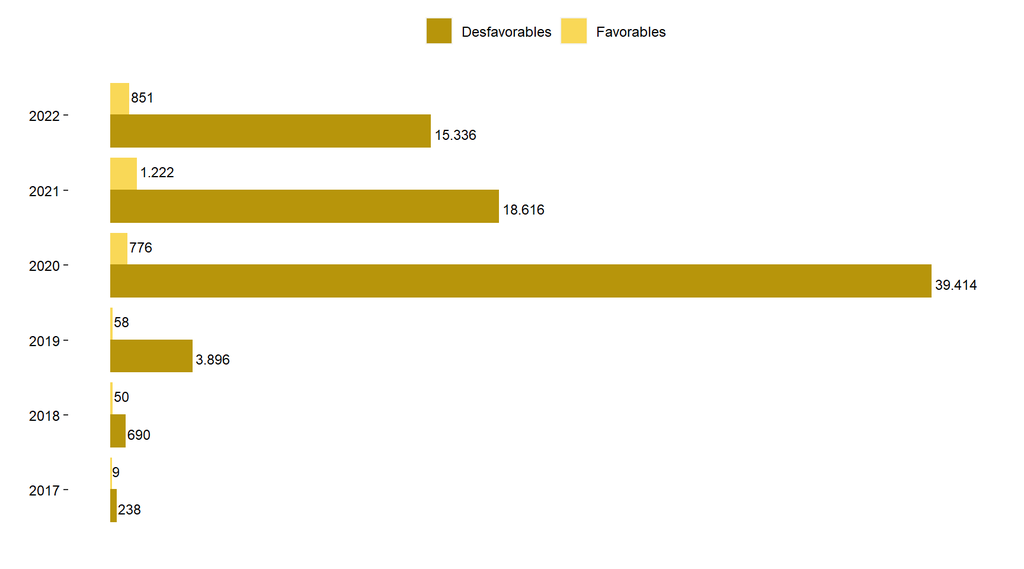

Tipo de resoluciones de solicitudes de Protección Internacional de personas nacionales de Colombia. 2022

| Resolución | Personas | % |
| --- | --- | --- |
| TOTAL | 16.187 | 100 |
| Reconocimiento condición de refugiado | 646 | 4 |
| Reconocimiento derecho a la protección subsidiaria | 12 | 0 |
| Autor. estancia o residencia por razones humanitarias | 193 | 1 |
| Resolución desfavorable | 15.336 | 95 |

Propuestas de resolución de solicitudes de Protección Internacional de personas nacionales de Colombia elevadas a la Comisión Interministerial de Asilo y Refugio. Enero─abril 2023

| Criterio de resolución | Propuestas | % |
| --- | --- | --- |
| TOTAL | 6.506 | 100 |
| Estatuto de refugiado | 231 | 4 |
| Protección subsidiaria | 5 | 0 |
| Razones humanitarias | 74 | 1 |
| Desfavorables | 5.993 | 92 |
| Archivo | 203 | 3 |

Fuente: [Oficina de Asilo y Refugio - Ministerio del Interior](https://www.interior.gob.es/opencms/es/servicios-al-ciudadano/tramites-y-gestiones/oficina-de-asilo-y-refugio/datos-e-informacion-estadistica/)

# 7. Beneficiarios del sistema de acogida y atención humanitaria

Nacionales de Colombia beneficiarios del Sistema de Acogida o Atención Humanitaria según sexo y tipo de recurso. 11/05/2023

[output not shown]

Nacionales de Colombia beneficiarios del Sistema de Acogida o Atención Humanitaria según comunidad autónoma de acogida. 11/05/2023

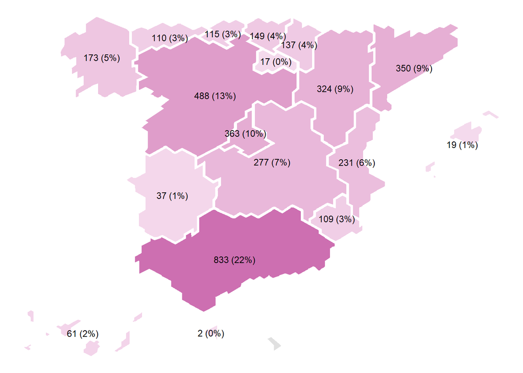

Fuente: SIRIA - MISSM

# 8. Menores no acompañados registrados en el Registro MENAs

**A 30/04/2023, última fecha disponible, había 22 menores no acompañados de Colombia** registrados en el Registro MENAs del Ministerio de Interior, el 0,2% del total. 11 son chicos (50%) y 11 chicas (50%).

Menores no acompañados de Colombia según comunidad autónoma de acogida. 30/04/2023

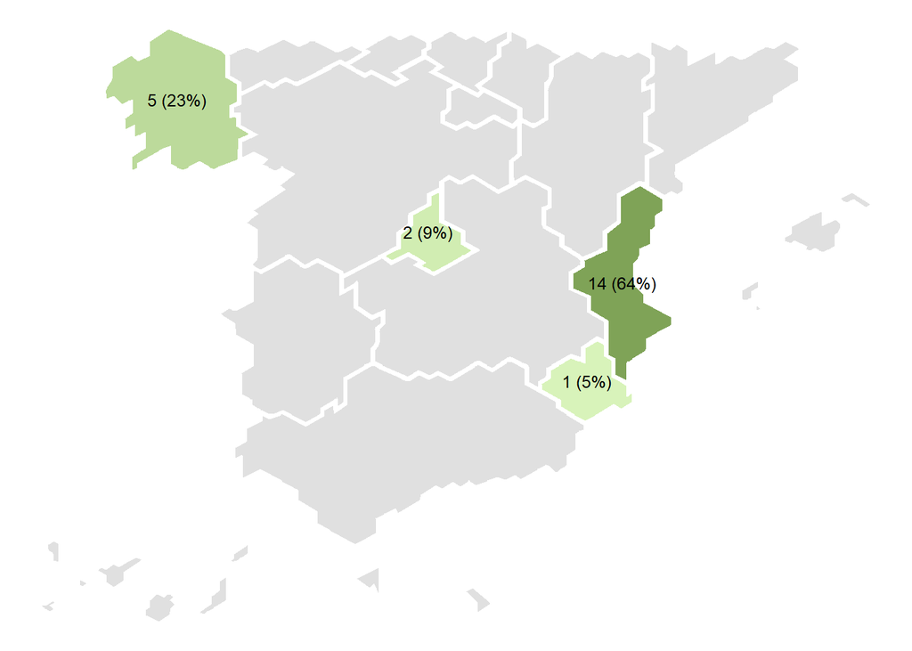

Evolución mensual del registro de menores no acompañados de Colombia, abril 2021 ─ abril 2023

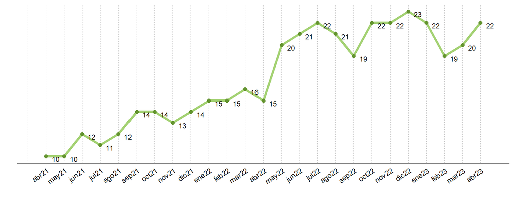

Fuente: Comisaría General de Extranjería y Fronteras - Ministerio del Interior

# 9. Evolución de los flujos regulares (visados y documentación de residencia)

9.1 Flujo de visados

Con respecto al flujo de visados, en 2021 se recuperó la movilidad de antes de la pandemia en general para todas las nacionalidades, aunque el número de visados de corta duración se redujo mucho por un cambio normativo de febrero de 2020 en el Código de Visados para las personas que viajan con frecuencia dentro del espacio Schengen, pudiendo entrar un mayor número de veces por más tiempo, reduciéndose el número de visados expedidos de corta duración de múltiples entradas.

En particular para los colombianos y peruanos, desde el 3 de diciembre de 2015 pueden viajar sólo con su pasaporte (sea el de zona de lectura mecánica o electrónico) a los países miembros de la Unión Europea si este tiene vigencia, como mínimo, de tres meses; es decir, sin necesidad de visado, explicando así la caída observada en 2016 del número de visados de corta duración.

Evolución de visados concedidos a ciudadanos de Colombia según clase de visado. 2012─2021

| Clase | 2012 | 2013 | 2014 | 2015 | 2016 | 2017 | 2018 | 2019 | 2020 | 2021 | % 2021 |
| --- | --- | --- | --- | --- | --- | --- | --- | --- | --- | --- | --- |
| TOTAL | 62.148 | 80.226 | 87.022 | 88.399 | 6.479 | 7.084 | 8.162 | 8.893 | 5.153 | 8.067 | 100 |
| Corta duración | 56.397 | 75.621 | 82.006 | 82.735 | 42 | 105 | 94 | 116 | 90 | 79 | 1 |
| Larga duración | 5.737 | 4.598 | 5.008 | 5.662 | 6.437 | 6.979 | 8.068 | 8.777 | 5.063 | 7.988 | 99 |
| Tránsito aeroportuario | 14 | 7 | 8 | 2 | 0 | 0 | 0 | 0 | 0 | 0 | 0 |

Evolución de visados concedidos a ciudadanos de Colombia según clase de visado de corta o larga duración. 2010─2021

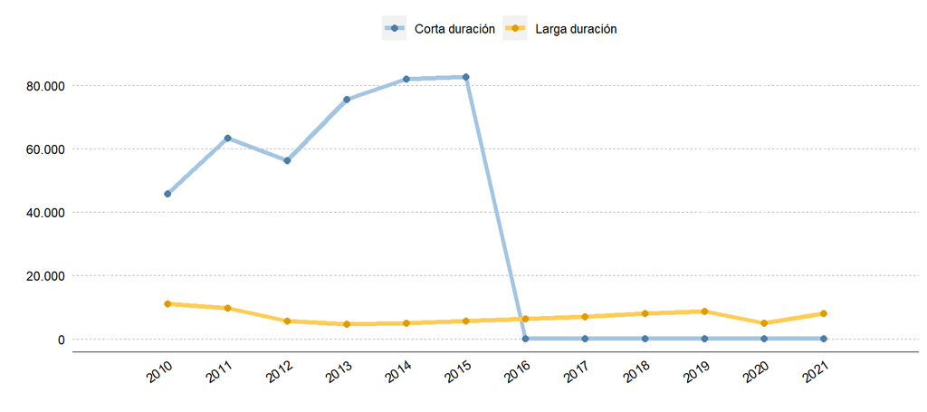

Visados expedidos a nacionales de Colombia según clase (corta o larga duración) y tipo/finalidad de visado. 2021

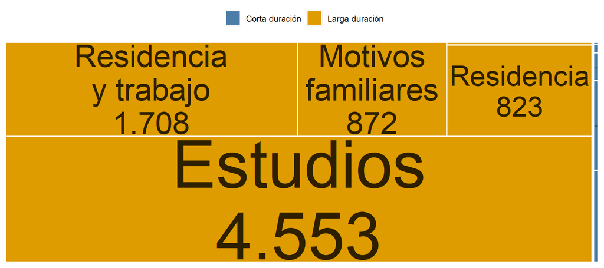

Fuente: [OPI - SGAM](https://www.inclusion.gob.es/web/opi/estadisticas/catalogo/visados)

Los visados de larga duración generalmente dan lugar a documentación de residencia.

9.2 Flujo de documentación de residencia

En los últimos 5 años se ha expedido documentación de residencia (autorizaciones de residencia y tarjetas de familiar de comunitario o de británico) a nacionales de Colombia por los siguientes motivos:

Autorizaciones de residencia de Régimen General concedidas a ciudadanos de Colombia según motivo. 2017─2021

| Motivo | 2017 | 2018 | 2019 | 2020 | 2021 |
| --- | --- | --- | --- | --- | --- |
| TOTAL | 10.667 | 12.418 | 14.733 | 17.426 | 29.986 |
| Residencia temporal. Circunstancias excepcionales | 1.591 | 2.206 | 3.666 | 6.444 | 14.622 |
| Residencia temporal. Trabajo cuenta ajena | 2.529 | 3.143 | 3.857 | 4.224 | 5.775 |
| Residencia larga duración | 3.428 | 3.384 | 2.703 | 1.971 | 2.707 |
| Residencia temporal. Ley 14/2013 y otras | 695 | 932 | 1.434 | 1.738 | 2.576 |
| Residencia temporal no lucrativa | 688 | 937 | 1.238 | 1.402 | 2.313 |
| Residencia temporal. Reagrupación familiar | 640 | 595 | 556 | 528 | 859 |
| Residencia duración determinada. Trabajo cuenta ajena | 474 | 602 | 622 | 580 | 448 |
| Residencia temporal. Trabajo cuenta propia | 185 | 197 | 248 | 268 | 319 |
| Residencia temporal. Excepción a la autorización de trabajo | 234 | 223 | 238 | 178 | 233 |
| Residencia larga duración-UE | 150 | 159 | 137 | 68 | 110 |
| Residencia temporal. Compatibilidad cuenta ajena y propia | 53 | 40 | 34 | 25 | 24 |

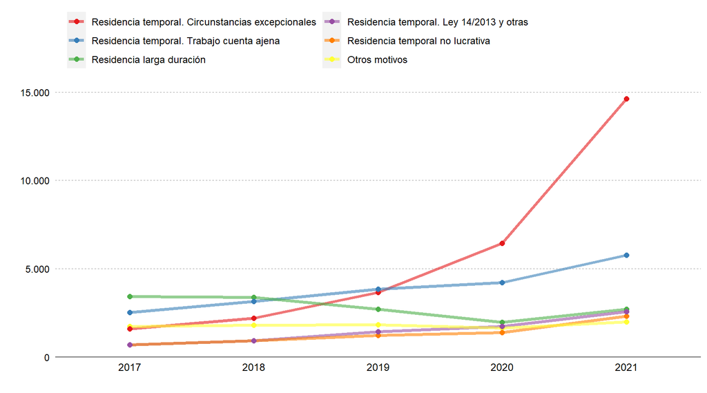

Tarjetas de familiar de ciudadano comunitario y TIE de familiar de británico beneficiario del acuerdo de retirada expedidas a nacionales de Colombia, según motivo. 2017─2021

| Motivo | 2017 | 2018 | 2019 | 2020 | 2021 |
| --- | --- | --- | --- | --- | --- |
| TOTAL | 10.387 | 12.261 | 13.169 | 11.287 | 14.161 |
| Familiar de UE-RU. Temporal | 8.091 | 9.804 | 10.750 | 9.323 | 11.123 |
| Familiar de UE-RU. Permanente | 2.296 | 2.457 | 2.419 | 1.964 | 3.038 |

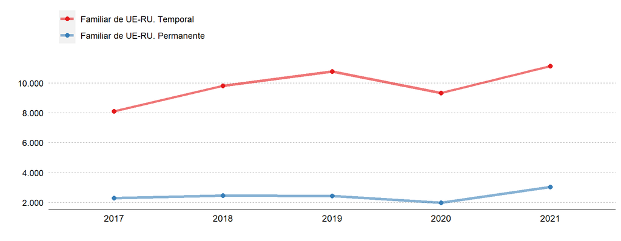

El siguiente gráfico muestra la **distribución de la documentación de residencia (autorizaciones de residencia y tarjetas de familiar de comunitario o de británico) concedida o expedida a nacionales de Colombia durante 2021, según tipo de trámite**:

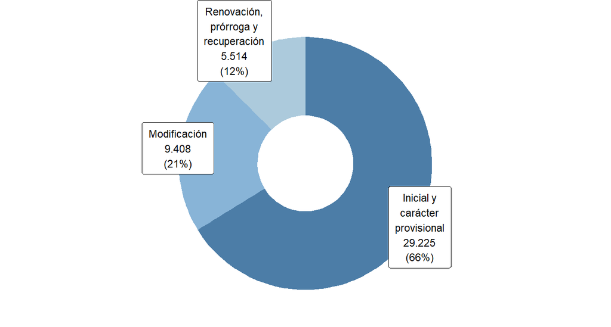

Fuente: [OPI - SGAM](https://www.inclusion.gob.es/web/opi/estadisticas/catalogo/flujo_autorizaciones)

**Comparando con el resto de países de la UE/AELC, el siguiente mapa muestra el número de *primeras* autorizaciones de residencia o de estancia por estudios expedidas a personas de nacionalidad colombiana durante 2021**, entendiendo como *primera* aquella autorización concedida a una persona si no le fue concedida ninguna otra en los 6 meses anteriores.

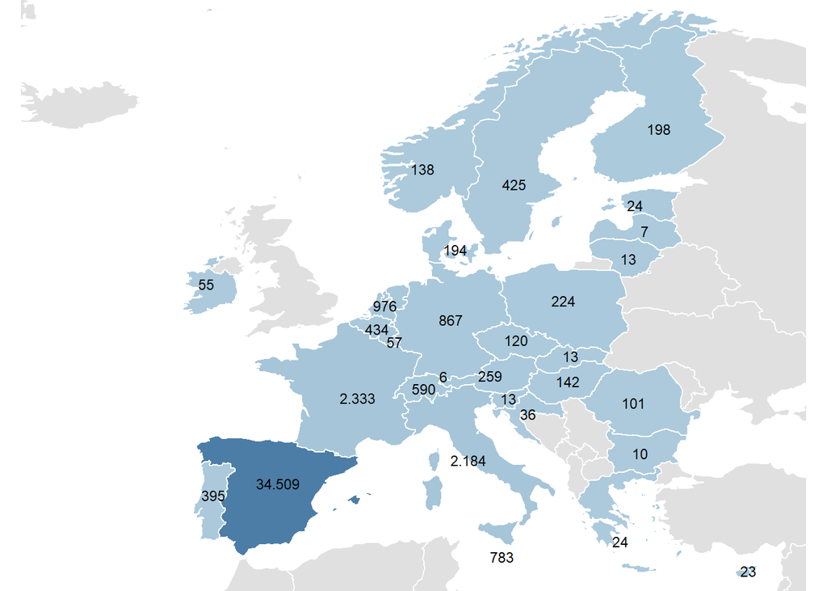

Sin dato disponible: Islandia

Fuente: [Eurostat](https://ec.europa.eu/eurostat/databrowser/view/migr_resfirst/default/table?lang=en)

# 10. Población española residente en Colombia

**A 01/01/2023, último dato publicado por el INE, había 44.925 españoles residentes en Colombia** inscritos en el fichero central del Padrón de españoles residentes en el extranjero (PERE); suponen el 2,7% de todos los españoles residentes en países de América.

| TOTAL | Hombres | % Hombres | Mujeres | % Mujeres |
| --- | --- | --- | --- | --- |
| 44.925 | 22.414 | 50 | 22.511 | 50 |

Evolución de los españoles residentes en Colombia. 2009─2023

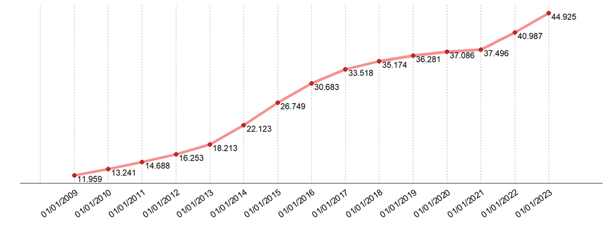

Fuente: [PERE - INE](https://www.ine.es/dyngs/INEbase/operacion.htm?c=Estadistica_C&cid=1254736177014&menu=resultados&secc=1254736195474&idp=1254734710990)